# Gaussian Processes

28/09/2021

## Content

The Gaussian Process is a natural extension of the multivariate Gaussian distribution which is a natural extension of the Gaussian distribution. As such the GP is going to be introduced in a series of steps:

1. Gaussian distribution
2. Bivariate Gaussian distribution
3. Multivariate Gaussian distribution
4. Gaussian Process distribution

## One Variable Data

In the following table \(X\) is a variable. Each row corresponds to a sample from that variable.

```
## # A tibble: 5 × 1
##        X
##    <dbl>
## 1 -1.20
## 2 -0.616
## 3  0.716
## 4 -0.275
## 5 -1.04
```

The **sample mean** and the **sample variance** are important properties of these data.

## Gaussian Distribution

The Gaussian distribution describes the probabilistic properties of a variable \(X\). The Gaussian distribution is parameterised by a mean and variance:

- The **mean** \(\mu\) is the centre of \(X\) values
- The **variance** \(\sigma^2\) is the spread of \(X\) values

If we assume a variable \(X\) has a Gaussian distribution with mean \(\mu\) and variance \(\sigma^2\) then \(X\sim N(\mu,\sigma^2)\).

## Gaussian Distribution

- \(\mu=0\)
- \(\sigma^2=1\)

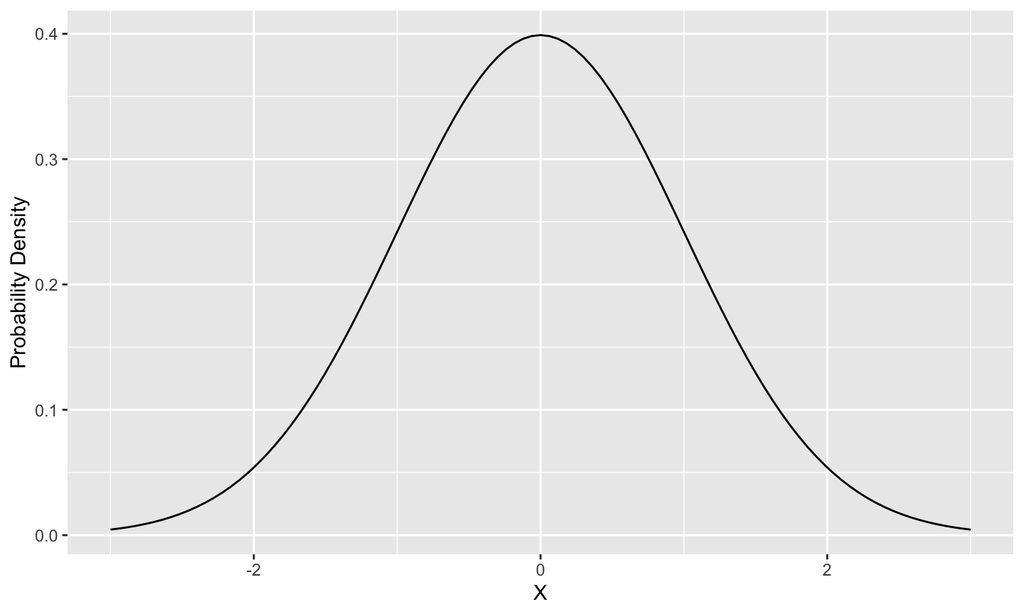

## Gaussian Distribution

- \(\mu=-1\) (decrease mean)
- \(\sigma^2=1\)

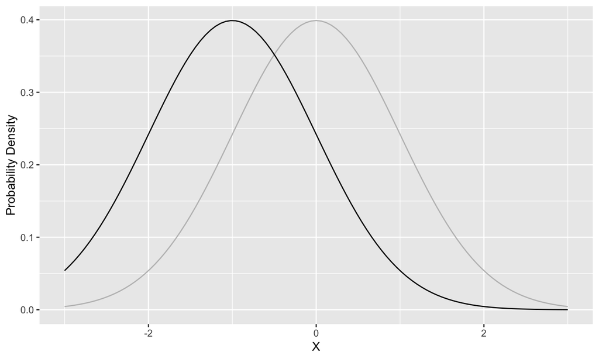

## Gaussian Distribution

- \(\mu=0\)
- \(\sigma^2=1\)

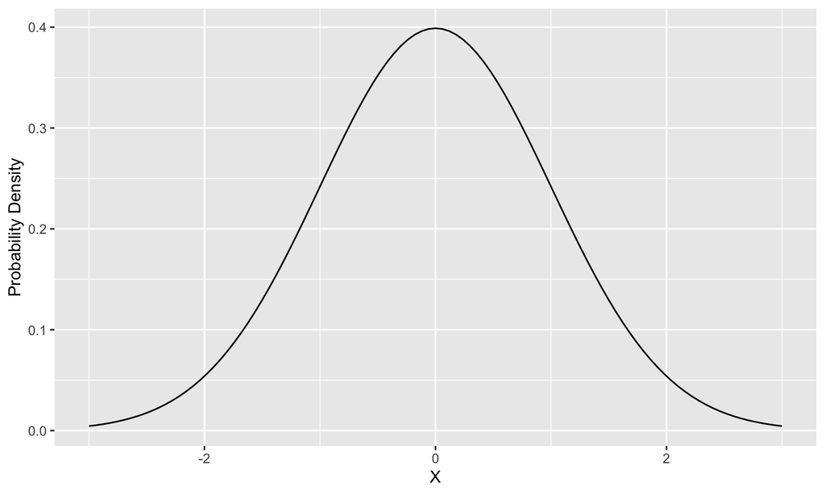

## Gaussian Distribution

- \(\mu=0\)
- \(\sigma^2=2\) (increase variance)

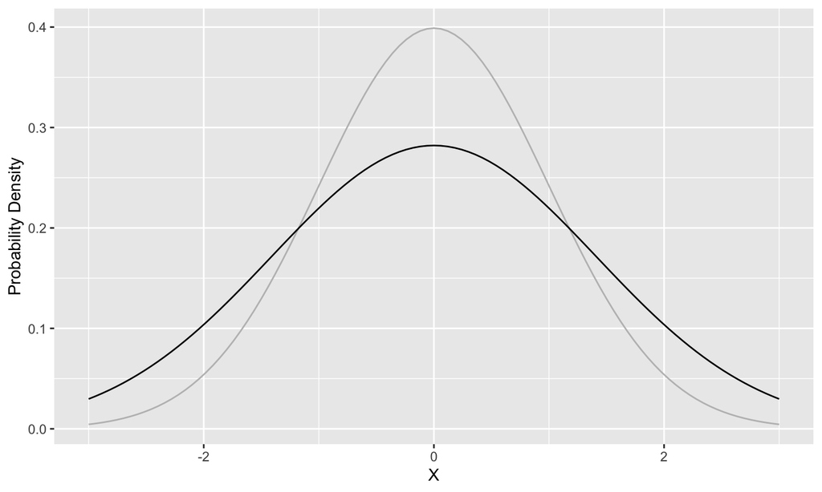

## Two Variable Data

In the following table \(X_1\) and \(X_2\) are variables. Each row corresponds to a sample from these variables.

```
## # A tibble: 5 × 2
##       X1     X2
##    <dbl>  <dbl>
## 1  0.249 -0.120
## 2  0.569  0.807
## 3 -0.654 -0.701
## 4  2.83   0.207
## 5  0.932  1.66
```

The **sample correlation** is an important property of these data.

## Bivariate Gaussian Distribution

The bivariate Gaussian distribution describes the probabilistic properties of two variables \(X_1\) and \(X_2\). The bivariate Gaussian distribution is parameterised by a mean and variance for each variable and a correlation for the pair of variables:

- The **mean** \(\mu_t\) is the centre of \(X_t\) values
- The **variance** \(\sigma^2_t\) is the spread of \(X_t\) values
- The **correlation** \(\rho\) is the association of \(X_1\) and \(X_2\) values

## Bivariate Gaussian Distribution

The means \(\mu_1\) and \(\mu_2\) can be collected into a **mean vector**:

\[ \boldsymbol\mu= \begin{bmatrix} \mu_1\\ \mu_2 \end{bmatrix} \]

The variances \(\sigma^2_1\) and \(\sigma^2_2\) and correlation \(\rho\) can be collected into a **variance matrix**:

\[ \boldsymbol\Sigma= \begin{bmatrix} \sigma_1^2 & \rho\sigma_1\sigma_2\\ \rho\sigma_2\sigma_1 & \sigma_2^2 \end{bmatrix} \]

If we assume the variables \(X_1\) and \(X_2\) have a bivariate Gaussian distribution with mean vector \(\boldsymbol\mu\) and variance matrix \(\boldsymbol\Sigma\) then \((X_1,X_2)\sim N_2(\boldsymbol\mu,\Sigma)\).

## Bivariate Gaussian Distribution

\[ \boldsymbol\Sigma= \begin{bmatrix} 1 & 0\\ 0 & 1 \end{bmatrix}\quad\text{(correlation of zero)} \]

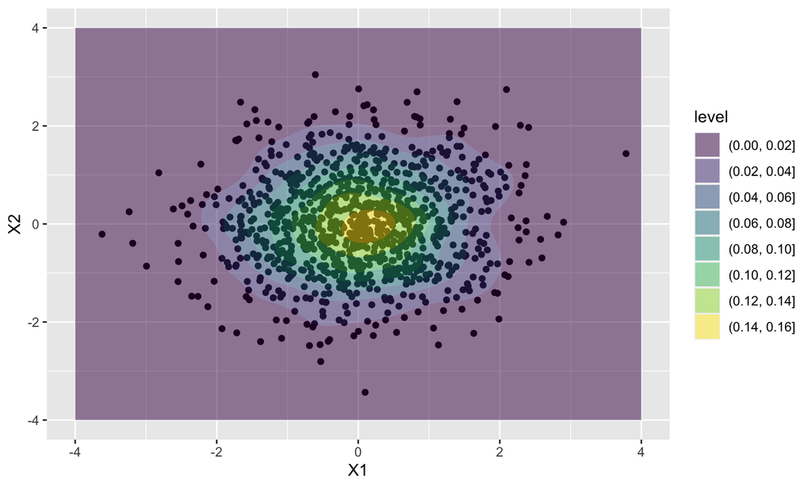

## Bivariate Gaussian Distribution

\[ \boldsymbol\Sigma= \begin{bmatrix} 1 & 0\\ 0 & 0.5 \end{bmatrix}\quad\text{(decrease X2 variance)} \]

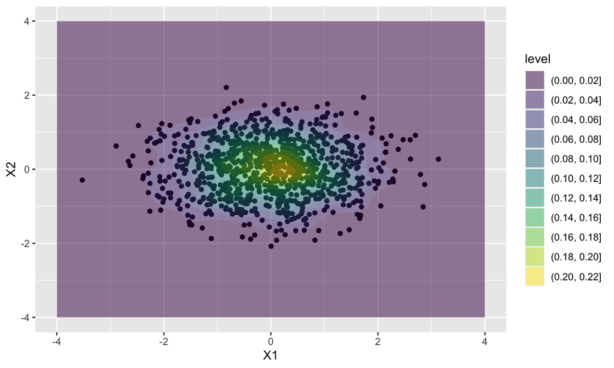

## Bivariate Gaussian Distribution

\[ \boldsymbol\Sigma= \begin{bmatrix} 1 & 0.8\\ 0.8 & 1 \end{bmatrix}\quad\text{(increase correlation)} \]

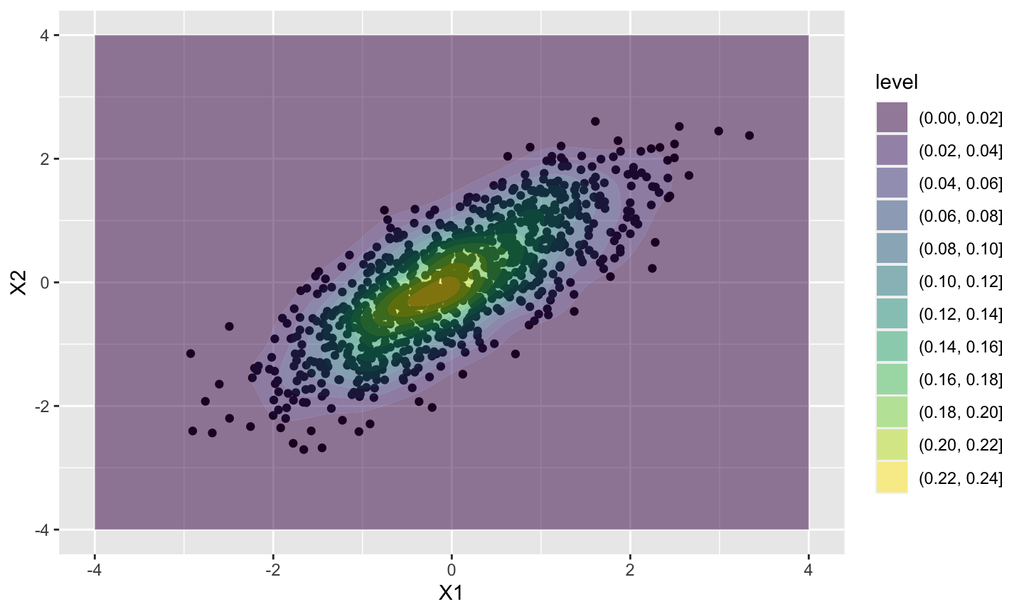

## Multivariate Gaussian Distribution

The multivariate Gaussian distribution describes the probabilistic properties of \(d\) variables \(X_1,\dots,X_d\). The multivariate Gaussian distribution is parameterised by a mean and variance for each variable and a correlation for each pair of variables:

- The **mean** \(\mu_t\) is the centre of \(X_t\) values
- The **variance** \(\sigma^2_t\) is the spread of \(X_t\) values
- The **correlation** \(\rho_{st}\) is the association of \(X_s\) and \(X_t\) values

## Multivariate Gaussian Distribution

The means \(\mu_1,\dots,\mu_d\) can be collected into a **mean vector**:

\[ \boldsymbol\mu= \begin{bmatrix} \mu_1\\ \vdots\\ \mu_d \end{bmatrix} \]

The variances \(\sigma^2_1,\dots,\sigma^2_d\) and correlations \(\rho_{st}\) can be collected into a **variance matrix**:

\[ \boldsymbol\Sigma_{st}=\rho_{st}\sigma_s\sigma_t \]

If we assume the variables \(X_1,\dots,X_d\) have a multivariate Gaussian distribution with mean vector \(\boldsymbol\mu\) and variance matrix \(\boldsymbol\Sigma\) then \((X_1,\dots,X_d)\sim N_d(\boldsymbol\mu,\boldsymbol\Sigma)\).

## Alternative Plot

Plotting samples from a multivariate (\(d>2\)) Gaussian distribution is impossible. This would require the screen to be three dimensional!

However, they can be plotted with an **index plot**.

## Index Plot (\(d=2\))

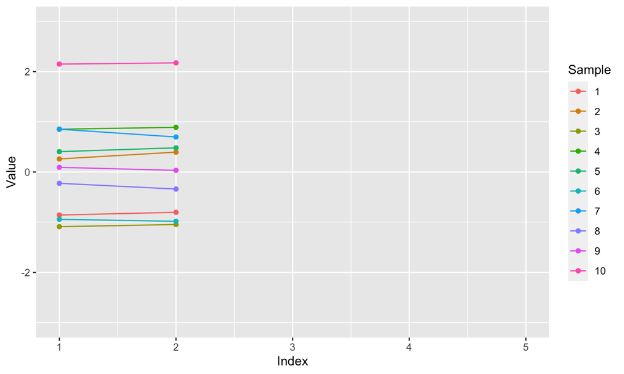

## Index Plot (\(d=5\))

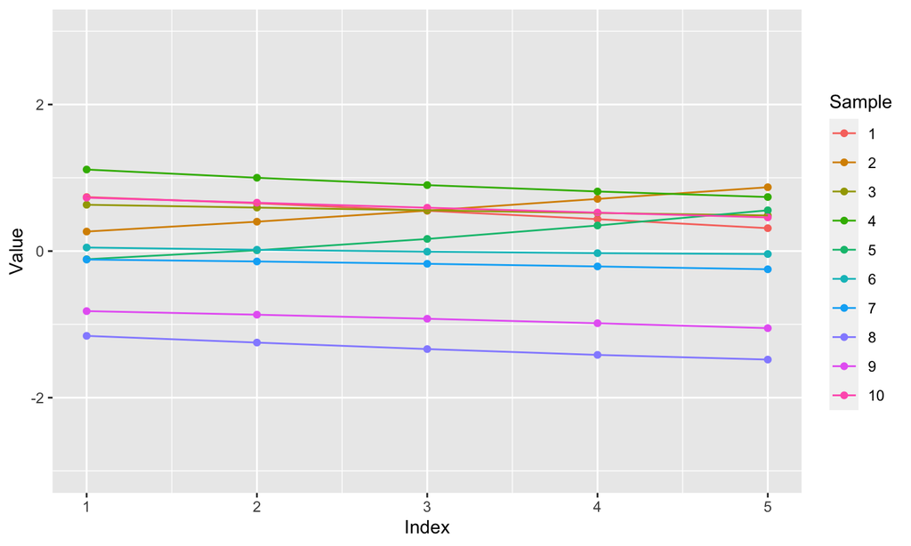

## Index Plot (\(d=50\))

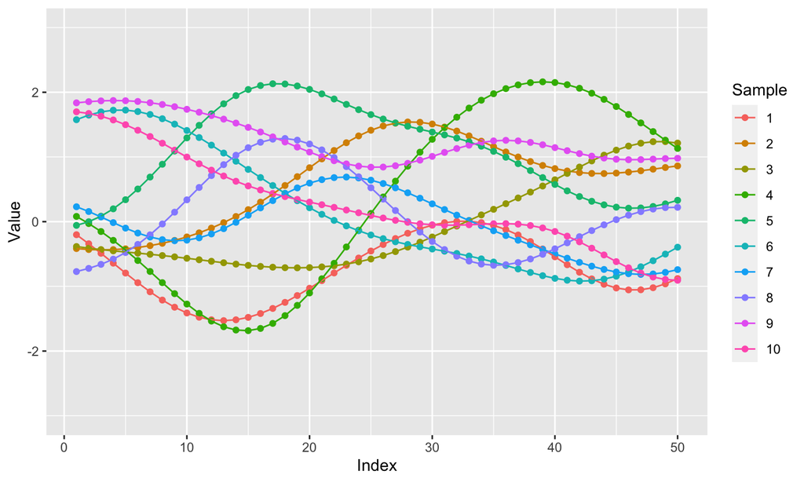

## Gaussian Process

Notice that samples from the \(50\)-dimensional multivariate Gaussian distribution are discrete functions over the index \(t\) from 1 to \(d\).

Is it possible to sample continuous functions over an index \(t\in\mathbb{R}\). This requires a **Gaussian Process** distribution.

## Gaussian Process

1. Multivariate Gaussian distribution requires a:
   - mean \(\mu_t\) for each \(t\) from 1 to \(d\).
   - variance \(\sigma^2_t\) for each \(t\) from 1 to \(d\)
   - correlation \(\rho_{st}\) for each \(s,t\) from 1 to \(d\)
2. Gaussian Process distribution requires a:
   - mean \(\mu(t)\) for each \(t\in\mathbb{R}\)
   - variance \(\sigma^2(t)\) for each \(t\in\mathbb{R}\)
   - correlation \(\rho(s,t)\) for each \(s,t\in\mathbb{R}\)

## Gaussian Process

- \(\mu(t)\) is the mean function
- \(\sigma^2(t)\) is the variance function
- \(\rho(s,t)\) is the correlation function

If we assume a function \(X(t)\) has Gaussian Process distribution with mean function \(\mu(t)\), variance function \(\sigma^2(t)\) and correlation function \(\rho(s,t)\) then \(X(t)\sim N_d(\mu(t),\sigma(s)\sigma(t)\rho(s,t))\).

[Gaussian Process Playground](https://durrande.shinyapps.io/gp_playground/)

*In the index plots we used a squared exponential covariance function with \(\sigma^2(t)=1\) and \(\theta=0.02\).*